# Example Commentary on International Defence

Ewan Keith

28 July 2015

# Comparing Defence Spending Between Countries

When trying to compare how much governments aroud the world spend on defence one issue is that different governments may use different definitions of what counts as defence spending. Whether or not spending on security agencies should be counted as defence expenditure is one example of the grey areas in setting out what *defence spending* is. In order to try and compare defence spending it can be helpful to sidestep this issue of definitions and use data collected by independant organisations which try and establish consistent rules regarding defence exenditure totals.

There are three high profile producers of international defence spending estimates, these are the [Stockholm International Peace Research Institute (SIPRI)](http://www.sipri.org), the [International Institute for Strategic Studies (IISS)](https://www.iiss.org), and [NATO](http://www.nato.int/).

If these estimates were completely reliable, and all based on common definitions of defence expenditure they could be expected to produce results very similar to one another. However, given the difficulty of producing accurate estimates of defence expenditure (along with the issue of definition) it’s likely that these estimates differ from one another.

This document explores to what extent the defence expenditure of the top 15 global spenders differs between the IISS ad SIPRI (NATO is not compared here as they only publish estimates for member states, not globally)

# IISS and SIPRI top 15 Spenders

|  | Country | IISS.Order | SIPRI.Order |
| --- | --- | --- | --- |
| 1 | USA | 1 | 1 |
| 2 | China | 2 | 2 |
| 3 | Saudi Arabia | 3 | 4 |
| 4 | Russia | 4 | 3 |
| 5 | UK | 5 | 6 |
| 6 | France | 6 | 5 |
| 7 | Japan | 7 | 9 |
| 8 | India | 8 | 7 |
| 9 | Germany | 9 | 8 |
| 10 | South Korea | 10 | 10 |

[output cut: 5 more lines]

Even limiting ourselves to the countries IISS lists as their top 15 it’s clear that there is quite significant disagreement between the two sources about how much countries are spending on defence. This could be caused by two things.

It could be that there are a small number of countries which the IISS and SIPRI differ on greatly. If one country were to jump up three places in one set of rankings this would displace all three of the coutnries above it, making a mess of the rankings (compared to the other organisation) when really only one country had a different total.

It could also be that the IISS and SIPRI in fact produce generally quite different estimates of defence expenditure across the board. This would be a much more serious issue for interpreting defence spending rankings than if there were just one or two troublesome countries.

Both IISS and SIPRI agree that the top two global spenders on defence are the USA and China. How close are their estimated total figures for these two countries?

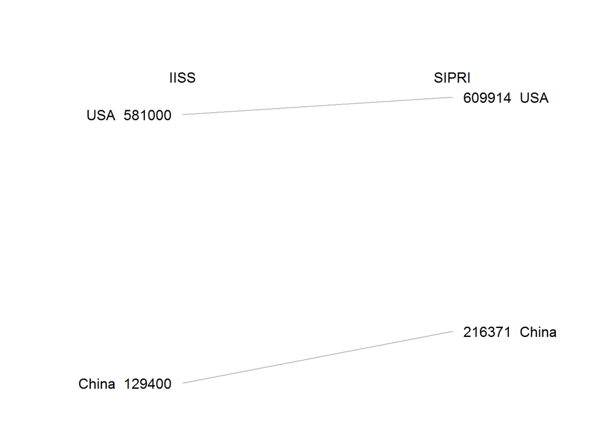

This is a huge difference in estimated spending, however it is possible that China is a one of case. What does the rest of the top 15 look like?

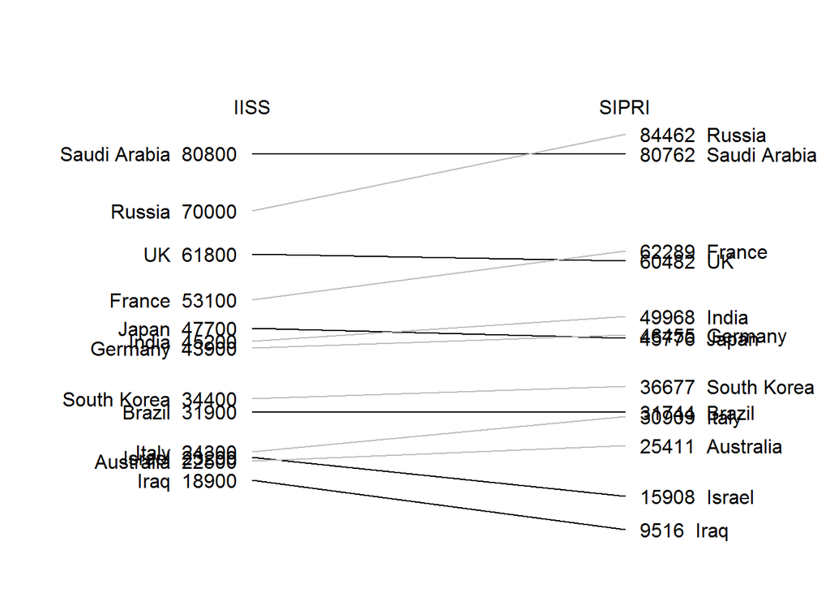